# Executing the Empirically Effective Modeling Methodology (EEM-M) in R

Takaki Hayashi (joint work with Takeaki Kariya and Hiroshi Kurata)

2024-01-20 (Preliminary version)

In this document, we introduce our R functions that enable data analysts to execute EEM-M in R. Specifically, we explain the main functions `setenv()` and `run_eem()` and their usage with concrete examples. (Note: ATTOW, the package is yet to be ready for distribution. Specifications of the functions can be modified through time.) The Shiny app **EEM-M** has been written based on these functions.

- Link to the **EEM-M** app: https://thayashi-kbs.shinyapps.io/eemmapp/

# 1 Gasoline consumption data (Chatterjee and Hadi, 2012)

As an illustration, we use the Gasoline consumption data described in Chatterjee and Hadi (2012), which is also referred in KKH(2023).

## 1.1 Description of the dataset:

- The gasoline consumption data (Y) in Motor Trend magazine for the year 1975.
- Source: Chatterjee and Hadi (2012) (Tables 9.16-9.17, pp255-256).
- The data is collected on 30 models of cars to study the factors that determine the gasoline consumption of cars.

```
The gasoline consumption data (Case 3). Chatterjee and Hadi (2012)
- K = 11, N = 30
- Y   Miles/gallon
- X2    Displacement (cubic inches)
- X3    Horsepower (feet/pound)
- X4    Torque (feet/pound)
- X5    Compression ratio
- X6    Rear axle ratio
- X7    Carburetor (barrels)
- X8    No. of transmission speeds
- X9    Overall length (inches)
- X10   Width (inches)
- X11   Weight (pounds)
- X12   Transmission type (1:automatic, 0:manual)
```

## 1.2 Summary statistics

```r
yX_df <- read.csv("../KKH/data/case3.csv")
Xmat <- yX_df[, -1]
Y_vec <- yX_df[, 1]
colnames(yX_df)[1] <- "y"
#
library(stargazer)
stargazer::stargazer(yX_df, type = "text",
                     summary.stat = c("n", "mean", "sd", "min", "p25", "median", "p75", "max"))
```

```
#>
#>  =========================================================================
#>  Statistic N    Mean    St. Dev.   Min   Pctl(25) Median  Pctl(75)   Max
#>  -------------------------------------------------------------------------
#>  y         30  20.040    6.263   11.200   16.430  19.300   21.500  36.500
#>  X2        30  285.700  116.000  85.300  226.500  318.000 351.000  500.000
#>  X3        30  137.000   44.650    70      106     141.5    165      223
#>  X4        30  217.900   83.070    81     171.2     243    258.8     366
#>  X5        30   8.313    0.277    8.000   8.000    8.325   8.500    9.000
#>  X6        30   3.059    0.529    2.450   2.710    3.000   3.243    4.300
#>  X7        30   2.567    1.073      1       2        2       4        4
#>  X8        30   3.333    0.661      3       3        3       3        5
#>  X9        30  192.300   21.030  155.700 173.400  196.000 207.000  231.000
#>  X10       30  71.420    5.678   61.800   65.780  72.000   76.300  79.800
#>  X11       30 3,626.000 941.000   1,905  3,028.0   3,760   4,215    5,430
#>  X12       30   0.733    0.450      0      0.2       1       1        1
#>  -------------------------------------------------------------------------
```

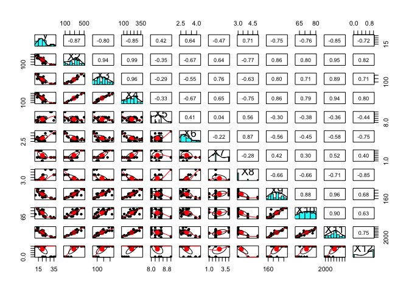

```r
#
#library(corrplot)
#cor.yX <- cor(yX_df)
#corrplot::corrplot.mixed(cor.yX) #  order = "AOE"
#
library(psych)
psych::pairs.panels(yX_df)
```

# 2 Conducting the EEM-M

The Empirically Effective Modelling methodology, or *EEM-M*, is proposed and developed in KKH (2024). It consists of two parts, *XMSP* and *yMSP*. There are two main functions, `setenv_eem()` and `run_eem()`, for that perticular purpose. In what follows, we are going to explain them.

#### Remarks about notation adopted and setups prepared in the program.

- $\tau$: index that differentiates models (sets of explanatory variables) of the same model size
- $J$: index that differentiate model sizes (number of explantory variables in a single model)
- The original explanatory variable matrix $X$ has the column index number starting from 1: $1,2,...,J$. This contrasts to KKH (24) that runs through $2,...,J$.
- The Post I-control can be executed after the VR / VI algorithm is done, which is not explicitly described in KKH (24). Note that the Pre I-control is prioritized when both Pre and Post are set to run.
- As alternatives of the model selection criterion in yMSP, AIC, BIC, adjusted $R^2$ are provided.

## 2.1 The function `setenv_eem()`

- The function `setenv_eem()` must be executed prior to the main function `run_eem()`, except when all the default values are used in `run_eem()`.
- It returns a list of the parameters that control computation and outputs made in `run_eem()`. The returned value shall be specified in the argument params in the subsequent `run_eem()`.

#### The list of parameters that can be set in `setenv_eem`, along with their respective default values.

```
# algorithm to be adopted
- algo = "VR",  # "VI"
# process control
- pca_VR = T,　# for VR only
- pre_Ictrl = T,
- post_Ictrl = F,
- do_yMSP = T,
# thresholds
- a_th = 0.9, # PC loading correlation. Ignored if pca_VR = F
- b_th = 0.4, # PCA relative contribution. Ignored if pca_VR = F
- cq_th = 0.95, # I-control
- dR_th = 0.9, # C-control
# output control
- keep_history = F,
- comp_ICRI = T
- prt_ext = T
- prt_progress = F,
- prt_details = F,
- write_output = T,
- output_id = "eem",
- output_path = "./out",
# criterion for yMSP
- ymsp_criteria = "AIC" # "BIC", "aR2",
# misc
- rm_rdn_ApwJp = "smaller" # "larger", "equiv"
- rm_rdn_VR = "none" # "smaller", "larger"
- rm_rdn_post_Ictrl = "none" # "smaller", "larger"
- nmod_max = 100 # upper limit allowed for cumulative models in the VI iteration
```

## 2.2 The function `run_eem()`

- This function executes XMSP and produce various outputs.
- It also execute yMSP if do_yMSP is TRUE, under which case the parameter ymsp_criteria specified in `setenv_eem()` is used to select the best OLS model.
- It returns a list of the outputs about selected models and accompanying information about the selection process.
- The explanatory variables x, as a matrix or a data.frame, and the response variable y must be provided as the first two arguments of the function.
- The third argument params must be provided as an output of setenv_eem(), except when the default parameter values are used altogher, in which case, the argument can be omitted.

[output not shown]

- Outputs of `run_eem()`: a list of elements including, but not limited to:

```
- summary: storing the most important results
  - xlab_initial
  - xlab_selected
  - n_models_selected_total
  - coef_best_model: Regression coefficients of the best model selected by yMSP with the chosen selection criterion ymsp_criteria
  - fit_best_model: The accompanying fit measures, together with the "risk measures" of the model prposed in KKH (24)
- xidx_selected: models (sets of variables) by XSMP. A list, each element of which has a data.frame object containing a set of variable indices (of the same length) selected by XMSP. The List of structure is used to differentiate model sizes, or the number of variables (index $J$) - xindices: various indices of each of selected models by XMSP
- status: record of the execution status of each step consisting of EEM-M
- params: parameters for the execution
- result_preIctrl: result of the pre I-control
- result_Cctrl: result of C-control
- result_ymsp: result of yMSP
- Xmat: explanatory data matrix $X(0)$
- y: response variable vector
```

### 2.2.1 Example 1: VI algorithm

- Setting for computation
  - The XMSP algorithm: “VI”
  - Pre I-control: TRUE, Threshold: $c_q=0.9$
  - Threshold for VI: $d_R=0.95$
  - Post I-control: FALSE
  - Model selection criterion for yMSP = adjusted $R^2$

```r
pars1 <- setenv_eem(algo = "VI", dR_th = 0.95, cq_th = 0.90,
             pre_Ictrl = T, post_Ictrl = F, prt_msgs = F,
             output_path = "results", ymsp_criteria = "aR2")
output1 <- run_eem(Xmat, Y_vec, params = pars1)
```

- Detailed contents of the output of `run_eem()`:
  - Refer to the Appendix.

#### Main results of XMSP

The `$summary` element of an output object of `run_eem()` contains a summary of the outcomes of the XMSP just conducted, together with that of the yMSP if it is also conducted.

```r
# summary of EEM-M
output1$summary
```

```
#>  $algo
#>  [1] "VI"
#>
#>  $xlab_initial
#>  [1] "X2,X3,X4,X5,X6,X7,X8,X9,X10,X11,X12"
#>
#>  $xlab_removed_by_preIctrl
#>  [1] "X3,X5,X6,X8,X9,X10,X11"
#>
#>  $cq
#>  [1] 0.9
#>
#>  $dR
#>  [1] 0.95
#>
#>  $xlab_selected
#>  $xlab_selected$J_1
#>  tau_1 tau_2 tau_3 tau_4
#>   "X2"  "X4"  "X7" "X12"
#>
#>  $xlab_selected$J_2
#>     tau_1    tau_2    tau_3    tau_4    tau_5
#>   "X2,X7"  "X4,X7" "X7,X12" "X2,X12" "X4,X12"
#>
#>  $xlab_selected$J_3
#>        tau_1       tau_2
#>  "X2,X7,X12" "X4,X7,X12"
#>
#>
#>  $n_models_selected_total
#>  [1] 11
#>
#>  $n_models_selected_each_J
#>  J_1 J_2 J_3
#>    4   5   2
#>
#>  $criteria
#>  [1] "aR2"
#>
#>  $coef_best_model
```

[output cut: 15 more lines]

```
#>    meas_ICctrld I_Risk C_Risk
#>  1        6.793  7.272  1.694
#>
#>
#>  $xidx_best_model
#>  $xidx_best_model$aR2
#>  [1] 1 6
#>
#>
#>  $xlab_best_model
#>      aR2
#>  "X2,X7"
#>
#>  $best_model_id
#>  [1] "J_2.tau_1"
```

**Selected models by XMSP**: The set of explanatory variables, or *models*, selected by XMSP will be stored in `$summary$xlab_selected`.

```r
output1$summary$xlab_selected
```

```
#>  $J_1
#>  tau_1 tau_2 tau_3 tau_4
#>   "X2"  "X4"  "X7" "X12"
#>
#>  $J_2
#>     tau_1    tau_2    tau_3    tau_4    tau_5
#>   "X2,X7"  "X4,X7" "X7,X12" "X2,X12" "X4,X12"
#>
#>  $J_3
#>        tau_1       tau_2
#>  "X2,X7,X12" "X4,X7,X12"
```

They will also be stored both in `$xlab_selected_matrix` and `$xlab_selected_df`, which have different formats as shown below.

```r
output1$xlab_selected_matrix
output1$xlab_selected_df
```

| ID | X2 | X3 | X4 | X5 | X6 | X7 | X8 | X9 | X10 | X11 | X12 |
| --- | --- | --- | --- | --- | --- | --- | --- | --- | --- | --- | --- |
| J_1.tau_1 | 1 | - | - | - | - | - | - | - | - | - | - |
| J_1.tau_2 | - | - | 1 | - | - | - | - | - | - | - | - |
| J_1.tau_3 | - | - | - | - | - | 1 | - | - | - | - | - |
| J_1.tau_4 | - | - | - | - | - | - | - | - | - | - | 1 |
| J_2.tau_1 | 1 | - | - | - | - | 1 | - | - | - | - | - |
| J_2.tau_2 | - | - | 1 | - | - | 1 | - | - | - | - | - |
| J_2.tau_3 | - | - | - | - | - | 1 | - | - | - | - | 1 |
| J_2.tau_4 | 1 | - | - | - | - | - | - | - | - | - | 1 |
| J_2.tau_5 | - | - | 1 | - | - | - | - | - | - | - | 1 |
| J_3.tau_1 | 1 | - | - | - | - | 1 | - | - | - | - | 1 |
| J_3.tau_2 | - | - | 1 | - | - | 1 | - | - | - | - | 1 |

| ID | x_selected |
| --- | --- |
| J_1.tau_1 | X2 |
| J_1.tau_2 | X4 |
| J_1.tau_3 | X7 |
| J_1.tau_4 | X12 |
| J_2.tau_1 | X2,X7 |
| J_2.tau_2 | X4,X7 |
| J_2.tau_3 | X7,X12 |
| J_2.tau_4 | X2,X12 |
| J_2.tau_5 | X4,X12 |
| J_3.tau_1 | X2,X7,X12 |
| J_3.tau_2 | X4,X7,X12 |

In the meantime, the set of explanatory variables selected will also be stored in `$xidx_selected`, described as indices (or positions) of the original explanatory variable matrix. This can be used for regression or other analyses afterwards.

```r
output1$xidx_selected
```

```
#>  $J_1
#>    tau_1 tau_2 tau_3 tau_4
#>  1     1     3     6    11
#>
#>  $J_2
#>    tau_1 tau_2 tau_3 tau_4 tau_5
#>  1     1     3     6     1     3
#>  2     6     6    11    11    11
#>
#>  $J_3
#>    tau_1 tau_2
#>  1     1     3
#>  2     6     6
#>  3    11    11
```

Total number of models selected by XMSP and (sub-)total number of models selected at each level of J (model size) are as follows:

```r
# total number of models selected by XMSP
output1$summary$n_models_selected_total
```

```
#>  [1] 11
```

```r
# (sub-)total number of models selected at each level of J (model size)
output1$summary$n_models_selected_each_J
```

```
#>  J_1 J_2 J_3
#>    4   5   2
```

**Performance measures of explanatory variables and those of the whole models**: Various performance measures of the respective variables in each of the selected models are stored in `$Hk_tbl` of `$xindices`.

- performance measures: $q^2_k, R^2_k, I_k, C_k, H_k$

```r
x_indices <- output1$xindices
(x_hktbl <- x_indices$Hk_tbl)
```

```
#>  $J_1.tau_1
#>
#>
#>  |   |    q2k|    R2k|    Ik|    Ck|    Hk|
#>  |:--|------:|------:|-----:|-----:|-----:|
#>  |X2 | 0.8625| 0.8625| 7.272| 7.272| 52.89|
#>
#>  $J_1.tau_2
#>
#>
#>  |   |    q2k|    R2k|    Ik|    Ck|   Hk|
#>  |:--|------:|------:|-----:|-----:|----:|
#>  |X4 | 0.8768| 0.8768| 8.118| 8.118| 65.9|
#>
#>  $J_1.tau_3
#>
#>
#>  |   |    q2k|    R2k|    Ik|    Ck|    Hk|
#>  |:--|------:|------:|-----:|-----:|-----:|
#>  |X7 | 0.8556| 0.8556| 6.923| 6.923| 47.93|
#>
#>  $J_1.tau_4
#>
#>
#>  |    |    q2k|    R2k|   Ik|   Ck|    Hk|
#>  |:---|------:|------:|----:|----:|-----:|
#>  |X12 | 0.7333| 0.7333| 3.75| 3.75| 14.06|
#>
#>  $J_2.tau_1
#>
#>
#>  |   |    q2k|    R2k|    Ik|    Ck|    Hk|
#>  |:--|------:|------:|-----:|-----:|-----:|
#>  |X2 | 0.8625| 0.4096| 7.272| 1.694| 12.32|
#>  |X7 | 0.8556| 0.4096| 6.923| 1.694| 11.73|
#>
#>  $J_2.tau_2
#>
#>
#>  |   |    q2k|    R2k|    Ik|    Ck|    Hk|
```

[output cut: 30 more lines]

```
#>
#>  |    |    q2k|    R2k|    Ik|    Ck|    Hk|
#>  |:---|------:|------:|-----:|-----:|-----:|
#>  |X2  | 0.8625| 0.7961| 7.272| 4.904| 35.67|
#>  |X7  | 0.8556| 0.4638| 6.923| 1.865| 12.91|
#>  |X12 | 0.7333| 0.7087| 3.750| 3.433| 12.87|
#>
#>  $J_3.tau_2
#>
#>
#>  |    |    q2k|    R2k|    Ik|    Ck|    Hk|
#>  |:---|------:|------:|-----:|-----:|-----:|
#>  |X4  | 0.8768| 0.7761| 8.118| 4.465| 36.25|
#>  |X7  | 0.8556| 0.4722| 6.923| 1.895| 13.12|
#>  |X12 | 0.7333| 0.6705| 3.750| 3.035| 11.38|
```

- Overall risk measures: $c_{MXK}, d_{MXK}, \bar{H}_k$

```r
output1$xindices$ICRI
```

| ID | cMXK | dMXK | Hbar |
| --- | --- | --- | --- |
| J_1.tau_1 | 7.272 | 7.272 | 52.887 |
| J_1.tau_2 | 8.118 | 8.118 | 65.900 |
| J_1.tau_3 | 6.923 | 6.923 | 47.929 |
| J_1.tau_4 | 3.750 | 3.750 | 14.062 |
| J_2.tau_1 | 7.272 | 1.694 | 12.021 |
| J_2.tau_2 | 8.118 | 1.744 | 13.115 |
| J_2.tau_3 | 6.923 | 1.185 | 6.326 |
| J_2.tau_4 | 7.272 | 3.117 | 17.180 |
| J_2.tau_5 | 8.118 | 2.794 | 16.577 |
| J_3.tau_1 | 7.272 | 4.904 | 20.484 |
| J_3.tau_2 | 8.118 | 4.465 | 20.250 |

#### Main results of yMSP

The best fitted model selected by the criterion specfied in the argument `ymsp_criteria` is also stored in the ouput object of `run_eem()`.

The value of the selection criterion of each model selected in XMSP and accompanying information are in `$result_ymsp$perf_summary`.

```r
output1$result_ymsp$perf_summary
```

| criterion | K | tau | xidx | value | xlab | ID |
| --- | --- | --- | --- | --- | --- | --- |
| aR2 | 1 | 1 | 1 | 0.7515 | X2 | J_1.tau_1 |
| aR2 | 1 | 2 | 3 | 0.7114 | X4 | J_1.tau_2 |
| aR2 | 1 | 3 | 6 | 0.1949 | X7 | J_1.tau_3 |
| aR2 | 1 | 4 | 11 | 0.5037 | X12 | J_1.tau_4 |
| aR2 | 2 | 1 | 1,6 | 0.7558 | X2,X7 | J_2.tau_1 |
| aR2 | 2 | 2 | 3,6 | 0.7136 | X4,X7 | J_2.tau_2 |
| aR2 | 2 | 3 | 6,11 | 0.5296 | X7,X12 | J_2.tau_3 |
| aR2 | 2 | 4 | 1,11 | 0.7423 | X2,X12 | J_2.tau_4 |
| aR2 | 2 | 5 | 3,11 | 0.7058 | X4,X12 | J_2.tau_5 |
| aR2 | 3 | 1 | 1,6,11 | 0.7473 | X2,X7,X12 | J_3.tau_1 |
| aR2 | 3 | 2 | 3,6,11 | 0.7043 | X4,X7,X12 | J_3.tau_2 |

**The best model by yMSP**: The best model is in `$summary$xlab_best_model` and `$summary$xidx_best_model`, the former of which is expressed as a string while the latter is as a vector of the indices (or positions) of the original explanatory matrix.

```r
output1$summary$xlab_best_model
```

```
#>      aR2
#>  "X2,X7"
```

```r
output1$summary$xidx_best_model
```

```
#>  $aR2
#>  [1] 1 6
```

The estimated coefficients and accompanying indices of the best model are in `$summary$coef_best_model`.

```r
output1$summary$coef_best_model
```

|  | Estimate | Std. Error | t value | Pr(>\|t\|) | PSE | q2k | R2k | Ik | Ck | Hk |
| --- | --- | --- | --- | --- | --- | --- | --- | --- | --- | --- |
| (Intercept) | 32.7424 | 1.6419 | 19.94 | 0.0000 | NA | NA | NA | NA | NA | NA |
| X2 | -0.0521 | 0.0064 | -8.08 | 0.0000 | 1.983 | 0.8625 | 0.4096 | 7.272 | 1.694 | 12.32 |
| X7 | 0.8505 | 0.6973 | 1.22 | 0.2331 | 1.935 | 0.8556 | 0.4096 | 6.923 | 1.694 | 11.73 |

The fit measures of the best model are in `$summary$fit_best_model`.

```r
output1$summary$fit_best_model
```

| n | K | df_residual | sigma | F_stat | p_val | R2 | aR2 | AIC | BIC | Hbar | meas_ICctrld | I_Risk | C_Risk |
| --- | --- | --- | --- | --- | --- | --- | --- | --- | --- | --- | --- | --- | --- |
| 30 | 2 | 27 | 3.095 | 45.87 | 0 | 0.7726 | 0.7558 | 70.63 | 74.83 | 12.02 | 6.793 | 7.272 | 1.694 |

### 2.2.2 Example 2: VR algorithm

- Setting for computation
  - The XMSP algorithm: “VR”
  - Pre I-control: FALSE
  - PCA: TRUE. $a=0.9, b=0.4$ (default)
  - Threshold for VR: $d_R=0.95$
  - Post I-control: TRUE. Threshold $c_q=0.94$

```r
# setup parameters
pars2 <- setenv_eem(algo = "VR",
                    a_th = 0.9, b_th = 0.4,
                    dR_th = 0.95, cq_th = 0.94,
             pre_Ictrl = F, post_Ictrl = T, prt_msgs = F,
             output_path = "results")
# run EEM, i.e., XMSP and yMSP together
output2 <- run_eem(Xmat, Y_vec, params = pars2)
```

#### Main results of XMSP

The `$summary` element of an output object of `run_eem()` contains a summary of the outcomes of the XMSP just conducted, together with that of the yMSP if it is also conducted.

```r
# summary of EEM-M
output2$summary
```

```
#>  $algo
#>  [1] "VR"
#>
#>  $xlab_initial
#>  [1] "X2,X3,X4,X5,X6,X7,X8,X9,X10,X11,X12"
#>
#>  $n_initial_models_generated_by_pca
#>  [1] 4
#>
#>  $para_pca
#>  # A tibble: 1 × 2
#>        a     b
#>    <dbl> <dbl>
#>  1   0.9   0.4
#>
#>  $xlab_removed_by_Ccontrol
#>  [1] "X11"
#>
#>  $dR
#>  [1] 0.95
#>
#>  $xlab_removed_by_postIctrl
#>  [1] "X5,X6,X8,X9,X10"
#>
#>  $cq
#>  [1] 0.94
#>
#>  $xlab_selected
#>  $xlab_selected$J_1
#>        tau_1       tau_2       tau_3
#>  "X2,X7,X12" "X3,X7,X12" "X4,X7,X12"
#>
#>  $xlab_selected$J_2
#>     tau_1
#>  "X7,X12"
#>
#>
#>  $n_models_selected_total
#>  [1] 4
#>
```

[output cut: 28 more lines]

```
#>    meas_ICctrld I_Risk C_Risk
#>  1        11.77  7.272  4.904
#>
#>
#>  $xidx_best_model
#>  $xidx_best_model$AIC
#>  [1]  1  6 11
#>
#>
#>  $xlab_best_model
#>          AIC
#>  "X2,X7,X12"
#>
#>  $best_model_id
#>  [1] "J_1.tau_1"
```

**Selected models by XMSP**: The set of explanatory variables, or *models*, selected by XMSP will be stored in `$summary$xlab_selected`.

```r
output2$summary$xlab_selected
```

```
#>  $J_1
#>        tau_1       tau_2       tau_3
#>  "X2,X7,X12" "X3,X7,X12" "X4,X7,X12"
#>
#>  $J_2
#>     tau_1
#>  "X7,X12"
```

They will also be stored both in `$xlab_selected_matrix` and `$xlab_selected_df`, which have different formats as shown below.

```r
output2$xlab_selected_matrix
output2$xlab_selected_df
```

| ID | X2 | X3 | X4 | X5 | X6 | X7 | X8 | X9 | X10 | X11 | X12 |
| --- | --- | --- | --- | --- | --- | --- | --- | --- | --- | --- | --- |
| J_1.tau_1 | 1 | - | - | - | - | 1 | - | - | - | - | 1 |
| J_1.tau_2 | - | 1 | - | - | - | 1 | - | - | - | - | 1 |
| J_1.tau_3 | - | - | 1 | - | - | 1 | - | - | - | - | 1 |
| J_2.tau_1 | - | - | - | - | - | 1 | - | - | - | - | 1 |

| ID | x_selected |
| --- | --- |
| J_1.tau_1 | X2,X7,X12 |
| J_1.tau_2 | X3,X7,X12 |
| J_1.tau_3 | X4,X7,X12 |
| J_2.tau_1 | X7,X12 |

In the meantime, the set of explanatory variables selected will also be stored in `$xidx_selected`, described as indices (or positions) of the original explanatory variable matrix. This can be used for regression or other analyses afterwards.

```r
output2$xidx_selected
```

```
#>  $J_1
#>    tau_1 tau_2 tau_3
#>  1     1     2     3
#>  2     6     6     6
#>  3    11    11    11
#>
#>  $J_2
#>    tau_1
#>  1     6
#>  2    11
```

Total number of models selected by XMSP and (sub-)total number of models selected at each level of J (model size) are as follows:

```r
# total number of models selected by XMSP
output2$summary$n_models_selected_total
```

```
#>  [1] 4
```

```r
# (sub-)total number of models selected at each level of J (model size)
output2$summary$n_models_selected_each_J
```

```
#>  J_1 J_2
#>    3   1
```

**Performance measures of explanatory variables and those of the whole models**: Various performance measures of the respective variables in each of the selected models are stored in `$Hk_tbl` of `$xindices`. - performance measures: $q^2_k, R^2_k, I_k, C_k, H_k$

```r
x_indices <- output2$xindices
(x_hktbl <- x_indices$Hk_tbl)
```

```
#>  $J_1.tau_1
#>
#>
#>  |    |    q2k|    R2k|    Ik|    Ck|    Hk|
#>  |:---|------:|------:|-----:|-----:|-----:|
#>  |X2  | 0.8625| 0.7961| 7.272| 4.904| 35.67|
#>  |X7  | 0.8556| 0.4638| 6.923| 1.865| 12.91|
#>  |X12 | 0.7333| 0.7087| 3.750| 3.433| 12.87|
#>
#>  $J_1.tau_2
#>
#>
#>  |    |    q2k|    R2k|     Ik|    Ck|     Hk|
#>  |:---|------:|------:|------:|-----:|------:|
#>  |X3  | 0.9068| 0.7766| 10.734| 4.477| 48.058|
#>  |X7  | 0.8556| 0.6215|  6.923| 2.642| 18.290|
#>  |X12 | 0.7333| 0.5516|  3.750| 2.230|  8.364|
#>
#>  $J_1.tau_3
#>
#>
#>  |    |    q2k|    R2k|    Ik|    Ck|    Hk|
#>  |:---|------:|------:|-----:|-----:|-----:|
#>  |X4  | 0.8768| 0.7761| 8.118| 4.465| 36.25|
#>  |X7  | 0.8556| 0.4722| 6.923| 1.895| 13.12|
#>  |X12 | 0.7333| 0.6705| 3.750| 3.035| 11.38|
#>
#>  $J_2.tau_1
#>
#>
#>  |    |    q2k|    R2k|    Ik|    Ck|    Hk|
#>  |:---|------:|------:|-----:|-----:|-----:|
#>  |X7  | 0.8556| 0.1564| 6.923| 1.185| 8.207|
#>  |X12 | 0.7333| 0.1564| 3.750| 1.185| 4.445|
```

- Overall risk measures: $c_{MXK}, d_{MXK}, \bar{H}_k$

```r
output2$xindices$ICRI
```

| ID | cMXK | dMXK | Hbar |
| --- | --- | --- | --- |
| J_1.tau_1 | 7.272 | 4.904 | 20.484 |
| J_1.tau_2 | 10.734 | 4.477 | 24.904 |
| J_1.tau_3 | 8.118 | 4.465 | 20.250 |
| J_2.tau_1 | 6.923 | 1.185 | 6.326 |

#### Main results of yMSP

The best fitted model selected by the criterion specfied in the argument `ymsp_criteria` is also stored in the ouput object of `run_eem()`.

The value of the selection criterion of each model selected in XMSP and accompanying information are in `$result_ymsp$perf_summary`.

```r
output2$result_ymsp$perf_summary
```

| criterion | K | tau | xidx | value | xlab | ID |
| --- | --- | --- | --- | --- | --- | --- |
| AIC | 3 | 1 | 1,6,11 | 72.51 | X2,X7,X12 | J_1.tau_1 |
| AIC | 3 | 2 | 2,6,11 | 80.43 | X3,X7,X12 | J_1.tau_2 |
| AIC | 3 | 3 | 3,6,11 | 77.23 | X4,X7,X12 | J_1.tau_3 |
| AIC | 2 | 1 | 6,11 | 90.29 | X7,X12 | J_2.tau_1 |

**The best model by yMSP**: The best model is in `$summary$xlab_best_model` and `$summary$xidx_best_model`, the former of which is expressed as a string while the latter is as a vector of the indices (or positions) of the original explanatory matrix.

```r
output2$summary$xlab_best_model
```

```
#>          AIC
#>  "X2,X7,X12"
```

```r
output2$summary$xidx_best_model
```

```
#>  $AIC
#>  [1]  1  6 11
```

The estimated coefficients and accompanying indices of the best model are in `$summary$coef_best_model`.

```r
output2$summary$coef_best_model
```

|  | Estimate | Std. Error | t value | Pr(>\|t\|) | PSE | q2k | R2k | Ik | Ck | Hk |
| --- | --- | --- | --- | --- | --- | --- | --- | --- | --- | --- |
| (Intercept) | 32.8170 | 1.6862 | 19.4616 | 0.0000 | NA | NA | NA | NA | NA | NA |
| X2 | -0.0550 | 0.0112 | -4.9261 | 0.0000 | 3.432 | 0.8625 | 0.7961 | 7.272 | 4.904 | 35.67 |
| X7 | 0.9223 | 0.7442 | 1.2393 | 0.2263 | 2.065 | 0.8556 | 0.4638 | 6.923 | 1.865 | 12.91 |
| X12 | 0.7663 | 2.4080 | 0.3182 | 0.7529 | 2.062 | 0.7333 | 0.7087 | 3.750 | 3.433 | 12.87 |

The fit measures of the best model are in `$summary$fit_best_model`.

```r
output2$summary$fit_best_model
```

| n | K | df_residual | sigma | F_stat | p_val | R2 | aR2 | AIC | BIC | Hbar | meas_ICctrld | I_Risk | C_Risk |
| --- | --- | --- | --- | --- | --- | --- | --- | --- | --- | --- | --- | --- | --- |
| 30 | 3 | 26 | 3.148 | 29.59 | 0 | 0.7735 | 0.7473 | 72.51 | 78.12 | 20.48 | 11.77 | 7.272 | 4.904 |

## 2.3 Other useful functions: `run_xmsp()` and `run_ymsp()`

Instead of running `run_eem()`, you can run seperately either `run_xmsp()` and/or `run_ymsp()` that specifically conduct XMSP and yMSP respectively both of which comprise the whole EEM-M. In fact, `run_eem()` is nothing more than a wrapper function of the two, so essentially the outputs altogether can essentially be equvalent to that from `run_eem()`.

```
run_xmsp(x,
         params = setenv_eem())
- x: a matrix or data frame of explantory variables
- params: an output object of <tt>setenv_eem()</tt>. A list of parameter values specified for yMSP.
```

```
run_ymsp(y,
         output_of_XMSP,
         params = setenv_eem())
- y: a response variable (vector)
- output_of_XMPS: an output object of <tt>run_xmsp()</tt>
- params: an output object of <tt>setenv_eem()</tt>. A list of parameter values specified for yMSP.
```

### 2.3.1 Example 3 (Example illustrated in 5.2 of KKH(23))

- Setting for computation
  - The XMSP algorithm: VR
  - Pre I-control: Yes. Threshold: $c_q=0.9$
  - PCA: TRUE. $a=0.9, b=0.4$ (default)
  - Threshold for VR: $d_R=0.9$
  - Post I-control: No
  - Model selection criterion for yMSP: AIC

```r
pars3 <- setenv_eem(algo = "VR",
        pca_VR = T,
        pre_Ictrl = T,
        post_Ictrl = F,
        do_yMSP = F,
        cq_th = 0.9, dR_th = 0.9,
        a_th = 0.9, b_th = 0.4,
        comp_ICRI = T,
        write_output = T,
        prt_msgs = F,
        output_id = "eem_eg3",
        output_path = "./results",
        ymsp_criteria = "AIC"
        )

# Execution of XMSP
out3_xmsp <- run_xmsp(Xmat, params = pars3)

# Execution of yMSP
out3_ymsp <- run_ymsp(Y_vec, out3_xmsp, params = pars3)
```

#### Main results of XMSP

The `$summary` element of an output object of `run_eem()` contains a summary of the outcomes of the XMSP just conducted, together with that of the yMSP if it is also conducted.

```r
# Summary of XMSP
out3_xmsp$summary
```

```
#>  $algo
#>  [1] "VR"
#>
#>  $xlab_initial
#>  [1] "X2,X3,X4,X5,X6,X7,X8,X9,X10,X11,X12"
#>
#>  $xlab_removed_by_preIctrl
#>  [1] "X3,X5,X6,X8,X9,X10,X11"
#>
#>  $cq
#>  [1] 0.9
#>
#>  $n_initial_models_generated_by_pca
#>  [1] 2
#>
#>  $para_pca
#>  # A tibble: 1 × 2
#>        a     b
#>    <dbl> <dbl>
#>  1   0.9   0.4
#>
#>  $dR
#>  [1] 0.9
#>
#>  $xlab_selected
#>  $xlab_selected$J_1
#>        tau_1       tau_2
#>  "X2,X7,X12" "X4,X7,X12"
#>
#>
#>  $n_models_selected_total
#>  [1] 2
#>
#>  $n_models_selected_each_J
#>  J_1
#>    2
```

**Selected models by XMSP**: The set of explanatory variables, or *models*, selected by XMSP will be stored in `$summary$xlab_selected`.

```r
out3_xmsp$summary$xlab_selected
```

```
#>  $J_1
#>        tau_1       tau_2
#>  "X2,X7,X12" "X4,X7,X12"
```

They will also be stored both in `$xlab_selected_matrix` and `$xlab_selected_df`, which have different formats as shown below.

```r
out3_xmsp$xlab_selected_matrix
out3_xmsp$xlab_selected_df
```

| ID | X2 | X3 | X4 | X5 | X6 | X7 | X8 | X9 | X10 | X11 | X12 |
| --- | --- | --- | --- | --- | --- | --- | --- | --- | --- | --- | --- |
| J_1.tau_1 | 1 | - | - | - | - | 1 | - | - | - | - | 1 |
| J_1.tau_2 | - | - | 1 | - | - | 1 | - | - | - | - | 1 |

| ID | x_selected |
| --- | --- |
| J_1.tau_1 | X2,X7,X12 |
| J_1.tau_2 | X4,X7,X12 |

In the meantime, the set of explanatory variables selected will also be stored in `$xidx_selected`, described as indices (or positions) of the original explanatory variable matrix. This can be used for regression or other analyses afterwards.

```r
out3_xmsp$xidx_selected
```

```
#>  $J_1
#>    tau_1 tau_2
#>  1     1     3
#>  2     6     6
#>  3    11    11
```

Total number of models selected by XMSP and (sub-)total number of models selected at each level of J (model size) are as follows:

```r
# total number of models selected by XMSP
out3_xmsp$summary$n_models_selected_total
```

```
#>  [1] 2
```

```r
# (sub-)total number of models selected at each level of J (model size)
out3_xmsp$summary$n_models_selected_each_J
```

```
#>  J_1
#>    2
```

**Performance measures of explanatory variables and those of the whole models**: Various performance measures of the respective variables in each of the selected models are stored in `$Hk_tbl` of `$xindices`. - performance measures: $q^2_k, R^2_k, I_k, C_k, H_k$

```r
x_indices <- out3_xmsp$xindices
(x_hktbl <- x_indices$Hk_tbl)
```

```
#>  $J_1.tau_1
#>
#>
#>  |    |    q2k|    R2k|    Ik|    Ck|    Hk|
#>  |:---|------:|------:|-----:|-----:|-----:|
#>  |X2  | 0.8625| 0.7961| 7.272| 4.904| 35.67|
#>  |X7  | 0.8556| 0.4638| 6.923| 1.865| 12.91|
#>  |X12 | 0.7333| 0.7087| 3.750| 3.433| 12.87|
#>
#>  $J_1.tau_2
#>
#>
#>  |    |    q2k|    R2k|    Ik|    Ck|    Hk|
#>  |:---|------:|------:|-----:|-----:|-----:|
#>  |X4  | 0.8768| 0.7761| 8.118| 4.465| 36.25|
#>  |X7  | 0.8556| 0.4722| 6.923| 1.895| 13.12|
#>  |X12 | 0.7333| 0.6705| 3.750| 3.035| 11.38|
```

- Overall risk measures: $c_{MXK}, d_{MXK}, \bar{H}_k$

```r
out3_xmsp$xindices$ICRI
```

| ID | cMXK | dMXK | Hbar |
| --- | --- | --- | --- |
| J_1.tau_1 | 7.272 | 4.904 | 20.48 |
| J_1.tau_2 | 8.118 | 4.465 | 20.25 |

#### Main results of yMSP

The best fitted model selected by the criterion specfied in the argument `ymsp_criteria` is stored in the ouput object of `run_ymsp()`.

The value of the selection criterion of each model selected in XMSP and accompanying information are in `$perf_summary`.

```r
out3_ymsp$perf_summary
```

| criterion | K | tau | xidx | value | xlab | ID |
| --- | --- | --- | --- | --- | --- | --- |
| AIC | 3 | 1 | 1,6,11 | 72.51 | X2,X7,X12 | J_1.tau_1 |
| AIC | 3 | 2 | 3,6,11 | 77.23 | X4,X7,X12 | J_1.tau_2 |

**The best model by yMSP**: The best model is in `$summary$xlab_best_model` and `$summary$xidx_best_model`, the former of which is expressed as a string while the latter is as a vector of the indices (or positions) of the original explanatory matrix.

```r
out3_ymsp$summary$xlab_best_model
```

```
#>          AIC
#>  "X2,X7,X12"
```

```r
out3_ymsp$summary$xidx_best_model
```

```
#>  $AIC
#>  [1]  1  6 11
```

The estimated coefficients and accompanying indices of the best model are in `$summary$coef_best_model`.

```r
out3_ymsp$summary$coef_best_model
```

|  | Estimate | Std. Error | t value | Pr(>\|t\|) | PSE | q2k | R2k | Ik | Ck | Hk |
| --- | --- | --- | --- | --- | --- | --- | --- | --- | --- | --- |
| (Intercept) | 32.8170 | 1.6862 | 19.4616 | 0.0000 | NA | NA | NA | NA | NA | NA |
| X2 | -0.0550 | 0.0112 | -4.9261 | 0.0000 | 3.432 | 0.8625 | 0.7961 | 7.272 | 4.904 | 35.67 |
| X7 | 0.9223 | 0.7442 | 1.2393 | 0.2263 | 2.065 | 0.8556 | 0.4638 | 6.923 | 1.865 | 12.91 |
| X12 | 0.7663 | 2.4080 | 0.3182 | 0.7529 | 2.062 | 0.7333 | 0.7087 | 3.750 | 3.433 | 12.87 |

The fit measures of the best model are in `$summary$fit_best_model`.

```r
out3_ymsp$summary$fit_best_model
```

| n | K | df_residual | sigma | F_stat | p_val | R2 | aR2 | AIC | BIC | Hbar | meas_ICctrld | I_Risk | C_Risk |
| --- | --- | --- | --- | --- | --- | --- | --- | --- | --- | --- | --- | --- | --- |
| 30 | 3 | 26 | 3.148 | 29.59 | 0 | 0.7735 | 0.7473 | 72.51 | 78.12 | 20.48 | 11.77 | 7.272 | 4.904 |

# 3 Utilization of the obtained results for further analysis

Output objects obtained from `run_eem()`, as well as `run_xmsp(), run_ymsp()`, can be recycled for further analysis in R and elsewhere.

## 3.1 Combining results of yMSP with standard regression results

Here, we recycle results of XMSP in Examples 1 and 2 above.

```r
# Best fitted model in light of AIC (indices)
mod1 <- output1$summary$xidx_best_model %>% unlist()
yxdf1 <- data.frame(y = Y_vec, Xmat[, mod1, drop = F])
lm_mod1 <- lm(y ~ ., data = yxdf1)

mod2 <- output2$summary$xidx_best_model %>% unlist()
yxdf2 <- data.frame(y = Y_vec, Xmat[, mod2, drop = F])
lm_mod2 <- lm(y ~ ., data = yxdf2)
```

As references, here we run standard regressions (OLS regression without variable selection, and stepwise regression). - Full model (OLS regression without variable selection)

- Stepwise regression

We aggregate all the results by using `stargazer()`:

```r
stargazer(res_ols, res_step, lm_mod1, lm_mod2,
          type = "text", # "html"
          digits = 3, digits.extra = 1, align = TRUE,
          report = "vct*",
          df = FALSE,
          dep.var.caption = 'Best model for',
          dep.var.labels = "", #NULL, #'Vote share (%)',
          model.numbers = F,
          title = 'Best models VI vs VR',
          column.labels = c("OLS", "Stepwise", "VI", "VR"),
          label = 'tbl:bestmod_VI_vs_VR'
)
```

```
#>
#>  Best models VI vs VR
#>  ========================================================================
#>                                         Best model for
#>                      ----------------------------------------------------
#>
#>                         OLS       Stepwise         VI            VR
#>  ------------------------------------------------------------------------
#>  X2                    -0.078                    -0.052        -0.055
#>                      t = -1.330               t = -8.080*** t = -4.926***
#>
#>  X3                    -0.073
#>                      t = -0.825
#>
#>  X4                    0.121
#>                      t = 1.326
#>
#>  X5                    1.329
#>                      t = 0.429
#>
#>  X6                    5.976        2.607
#>                      t = 1.892*  t = 2.063**
#>
#>  X7                    0.304                      0.851         0.922
#>                      t = 0.236                  t = 1.220     t = 1.239
#>
#>  X8                    -3.199
#>                      t = -1.030
#>
#>  X9                    0.185        0.218
#>                      t = 1.434   t = 2.485**
#>
#>  X10                   -0.399
#>                      t = -1.233
#>
#>  X11                   -0.005      -0.009
#>                      t = -0.881 t = -4.759***
#>
#>  X12                   0.599                                    0.766
#>                      t = 0.198                                t = 0.318
#>
#>  Constant              17.770       4.495        32.740        32.820
#>                      t = 0.583    t = 0.382   t = 19.940*** t = 19.460***
#>
#>  ------------------------------------------------------------------------
#>  Observations            30          30            30            30
#>  R2                    0.835        0.803         0.773         0.773
#>  Adjusted R2           0.735        0.781         0.756         0.747
#>  Residual Std. Error   3.226        2.932         3.095         3.148
#>  F Statistic          8.297***    35.430***     45.870***     29.590***
#>  ========================================================================
#>  Note:                                        *p<0.1; **p<0.05; ***p<0.01
```

## 3.2 Visualing various measures produced in XMSP

```r
# Among the output object, extract indices of each variable in each of selected models by XMSP
x_indices <- output2$xindices
(x_hktbl <- x_indices$Hk_tbl)　# Object containing various indices of each variable (stored in each selected model)
```

```
#>  $J_1.tau_1
#>         q2k    R2k    Ik    Ck    Hk
#>  X2  0.8625 0.7961 7.272 4.904 35.67
#>  X7  0.8556 0.4638 6.923 1.865 12.91
#>  X12 0.7333 0.7087 3.750 3.433 12.87
#>
#>  $J_1.tau_2
#>         q2k    R2k     Ik    Ck     Hk
#>  X3  0.9068 0.7766 10.734 4.477 48.058
#>  X7  0.8556 0.6215  6.923 2.642 18.290
#>  X12 0.7333 0.5516  3.750 2.230  8.364
#>
#>  $J_1.tau_3
#>         q2k    R2k    Ik    Ck    Hk
#>  X4  0.8768 0.7761 8.118 4.465 36.25
#>  X7  0.8556 0.4722 6.923 1.895 13.12
#>  X12 0.7333 0.6705 3.750 3.035 11.38
#>
#>  $J_2.tau_1
#>         q2k    R2k    Ik    Ck    Hk
#>  X7  0.8556 0.1564 6.923 1.185 8.207
#>  X12 0.7333 0.1564 3.750 1.185 4.445
```

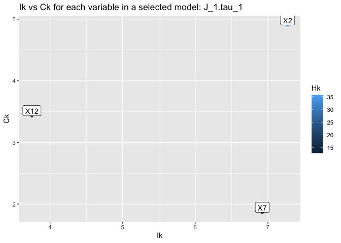

```r
# Scatter plot of pairs of model risk measures for one model selected by XMSP
# Comparison of variables within a selected model
l <- 1
ggplot(data = x_hktbl[[l]],
       aes(x = Ik, y = Ck) ) +
  geom_point(aes(colour = Hk)) +
  geom_label(aes(label = rownames(x_hktbl[[l]]), hjust = 0.5, vjust = 0)) +
  labs(title = paste0("Ik vs Ck for each variable in a selected model: ",  names(x_indices$Hk_tbl)[l]))
```

```r
# Extract overall model perforamnce measures of the selected models by XMSP
(tau_cdH <- x_indices$ICRI)
```

| ID | cMXK | dMXK | Hbar |
| --- | --- | --- | --- |
| J_1.tau_1 | 7.272 | 4.904 | 20.484 |
| J_1.tau_2 | 10.734 | 4.477 | 24.904 |
| J_1.tau_3 | 8.118 | 4.465 | 20.250 |
| J_2.tau_1 | 6.923 | 1.185 | 6.326 |

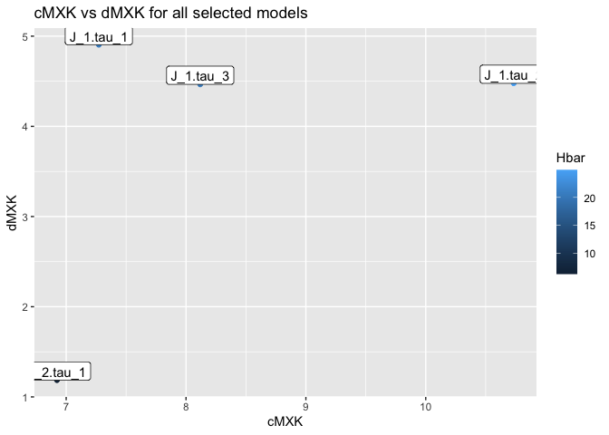

```r
# Scatter plot of two risk measures cMXK and dMXK for models selected by XMSP
# Comparison of selected models in terms of risk measures
ggplot(data = tau_cdH,
       aes(x = cMXK, y = dMXK) ) +
  geom_point(aes(colour = Hbar)) +
  geom_label(aes(label = ID, hjust = 0.5, vjust = 0)) +
  labs(title = paste0("cMXK vs dMXK for all selected models"))
```

## 3.3 Storing the key outputs as text files

By setting the argument `write_output == T` in `setenv_eem()`, the model selection results can be stored as text files. You can change the prefix of output file names (default value: “eem”)

#### Outputs of XMSP

Three types of text files will be produced. Each has a distinct format, but carry the same content as a whole. Here, described in the case of algo = “VR”, However, it is essentially the same for “VI”.

- Format 1: “eem_VR_J[n]_index.csv” ([n] contains index number that runs in VI or VI.) (Store the index of each variable in one model as an integer in a separate cell. Since the number of variables used depends on the size of J, the variables are to be stored in separate files for each size of J.)
- Format 2: “eem_VR_label.csv” (All variable labels in one model are stored in one cell as comma “,” as a delimitor)
- Format 3: “eem_VR_matrix.csv” (Matrix format in which each variable is arranged in columns and each model in rows, with 1 in the cell position corresponding to the variable selected in the model and missing values in all other positions.)

#### Outputs of yMSP

Among ouput lists in `run_ymsp()` and `run_eem()`, the regression coefficients and their various indices in the best fitted model (`summary$coef_best_model`), as well as its various model fit measures (`summary$fit_best_model`) will be stored as text files.

- Default file name: “eem_VR_ymsp.txt”

# Appendix

### The structure of outputs of run_eem()

- An output from Example 1 above.

```r
# The structure of a list object produce by run_eem(): An example
str(output1, max.level = 2)
```

```
#>  List of 12
#>   $ params              :List of 24
#>    ..$ algo             : chr "VI"
#>    ..$ pca_VR           : logi TRUE
#>    ..$ pre_Ictrl        : logi TRUE
#>    ..$ post_Ictrl       : logi FALSE
#>    ..$ do_yMSP          : logi TRUE
#>    ..$ a_th             : num 0.9
#>    ..$ b_th             : num 0.4
#>    ..$ cq_th            : num 0.9
#>    ..$ dR_th            : num 0.95
#>    ..$ keep_history     : logi FALSE
#>    ..$ comp_ICRI        : logi TRUE
#>    ..$ prt_ext          : logi TRUE
#>    ..$ prt_progress     : logi FALSE
#>    ..$ prt_details      : logi FALSE
#>    ..$ prt_msgs         : logi FALSE
#>    ..$ write_output     : logi TRUE
#>    ..$ output_id        : chr "eem"
#>    ..$ output_path      : chr "results"
#>    ..$ ymsp_criteria    : chr "aR2"
#>    ..$ rm_rdn_ApwJp     : chr "smaller"
#>    ..$ rm_rdn_VR        : chr "none"
#>    ..$ rm_rdn_post_Ictrl: chr "none"
#>    ..$ nmod_max         : num 100
#>    ..$ para_vec         : chr [1:21] "algo" "pca_VR" "pre_Ictrl" "post_Ictrl" ...
#>    ..- attr(*, "class")= chr "setenv_eem"
#>   $ summary             :List of 14
#>    ..$ algo                    : chr "VI"
#>    ..$ xlab_initial            : chr "X2,X3,X4,X5,X6,X7,X8,X9,X10,X11,X12"
#>    ..$ xlab_removed_by_preIctrl: chr "X3,X5,X6,X8,X9,X10,X11"
#>    ..$ cq                      : num 0.9
#>    ..$ dR                      : num 0.95
#>    ..$ xlab_selected           :List of 3
#>    ..$ n_models_selected_total : int 11
#>    ..$ n_models_selected_each_J: Named int [1:3] 4 5 2
#>    .. ..- attr(*, "names")= chr [1:3] "J_1" "J_2" "J_3"
#>    ..$ criteria                : chr "aR2"
#>    ..$ coef_best_model         :List of 1
#>    ..$ fit_best_model          :List of 1
```

[output cut: 62 more lines]

```
#>    ..$ X12: int [1:30] 1 1 1 1 0 1 1 1 0 0 ...
#>   $ y                   : num [1:30] 18.9 17 20 18.3 20.1 11.2 22.1 21.5 34.7 30.4 ...
#>   $ result_ymsp         :List of 9
#>    ..$ best_model            :List of 1
#>    ..$ coef_best_model       :List of 1
#>    ..$ fit_best_model        :List of 1
#>    ..$ xidx_best_model       :List of 1
#>    ..$ xlab_best_model       : Named chr "X2,X7"
#>    .. ..- attr(*, "names")= chr "aR2"
#>    ..$ best_model_each_J     :List of 1
#>    ..$ coef_best_model_each_J:List of 1
#>    ..$ fit_best_model_each_J :List of 1
#>    ..$ perf_summary          :List of 1
#>    ..- attr(*, "class")= chr "ymsp"
#>   - attr(*, "class")= chr "xmsp"
```

# References

- Takeaki Kariya, Hiroshi Kurata, and Takaki Hayashi (2024). A Modelling Framework for Regression with Collinearity, *Journal of Statistical Planning and Inference*, **228** (1), Pages 95-115.
- Chatterjee Samprit, Hadi Ali S. *Regression Analysis by Example (fifth ed.)*, Jhon Wiley, New York (2012).